# BUISNESS CASE: WITH THE FIFA20 DATASET WE NEED TO CLUSTER THE PLAYER BY THEIR SKILL INTO CERTAIN GROUP

# IMPORTING THE PYTHON LIBRARY

```python
import pandas as pd
import numpy as np
import matplotlib.pyplot as plt
%matplotlib inline
import seaborn as sns
from scipy import stats
import warnings
warnings.filterwarnings('ignore')
```

# LOAD DATA

```python
data = pd.read_csv('players_20.csv',na_filter=['+#'])
pd.set_option('display.max_columns',None)
data.head()
```

|  | sofifa_id | player_url | short_name | long_name | age | dob | height_cm | weight_kg | nationality | club | overall | potential | value_eur | wage_eur | player_positions | preferred_foot | international_reputation | weak_foot | skill_moves | work_rate | body_type | real_face | release_clause_eur | player_tags | team_position | team_jersey_number | loaned_from | joined | contract_valid_until | … |
| --- | --- | --- | --- | --- | --- | --- | --- | --- | --- | --- | --- | --- | --- | --- | --- | --- | --- | --- | --- | --- | --- | --- | --- | --- | --- | --- | --- | --- | --- | --- |
| 0 | 158023 | https://sofifa.com/player/158023/lionel-messi/... | L. Messi | Lionel Andrés Messi Cuccittini | 32 | 1987-06-24 | 170 | 72 | Argentina | FC Barcelona | 94 | 94 | 95500000 | 565000 | RW, CF, ST | Left | 5 | 4 | 4 | Medium/Low | Messi | Yes | 195800000.0 | #Dribbler, #Distance Shooter, #Crosser, #FK Sp... | RW | 10.0 | NaN | 2004-07-01 | 2021.0 | … |
| 1 | 20801 | https://sofifa.com/player/20801/c-ronaldo-dos-... | Cristiano Ronaldo | Cristiano Ronaldo dos Santos Aveiro | 34 | 1985-02-05 | 187 | 83 | Portugal | Juventus | 93 | 93 | 58500000 | 405000 | ST, LW | Right | 5 | 4 | 5 | High/Low | C. Ronaldo | Yes | 96500000.0 | #Speedster, #Dribbler, #Distance Shooter, #Acr... | LW | 7.0 | NaN | 2018-07-10 | 2022.0 | … |
| 2 | 190871 | https://sofifa.com/player/190871/neymar-da-sil... | Neymar Jr | Neymar da Silva Santos Junior | 27 | 1992-02-05 | 175 | 68 | Brazil | Paris Saint-Germain | 92 | 92 | 105500000 | 290000 | LW, CAM | Right | 5 | 5 | 5 | High/Medium | Neymar | Yes | 195200000.0 | #Speedster, #Dribbler, #Playmaker , #Crosser,... | CAM | 10.0 | NaN | 2017-08-03 | 2022.0 | … |
| 3 | 200389 | https://sofifa.com/player/200389/jan-oblak/20/... | J. Oblak | Jan Oblak | 26 | 1993-01-07 | 188 | 87 | Slovenia | Atlético Madrid | 91 | 93 | 77500000 | 125000 | GK | Right | 3 | 3 | 1 | Medium/Medium | Normal | Yes | 164700000.0 | NaN | GK | 13.0 | NaN | 2014-07-16 | 2023.0 | … |
| 4 | 183277 | https://sofifa.com/player/183277/eden-hazard/2... | E. Hazard | Eden Hazard | 28 | 1991-01-07 | 175 | 74 | Belgium | Real Madrid | 91 | 91 | 90000000 | 470000 | LW, CF | Right | 4 | 4 | 4 | High/Medium | Normal | Yes | 184500000.0 | #Speedster, #Dribbler, #Acrobat | LW | 7.0 | NaN | 2019-07-01 | 2024.0 | … |

# DOMAIN ANALYSIS

INTRODUCTION OF PROJECT:

FIFA 20 is a football simulation video game published by Electronic Arts as part of the FIFA series. It is the 27th installment in the FIFA series, and was released on 27 September 2019 for Microsoft Windows, PlayStation 4, Xbox One, and Nintendo Switch.

SOFIFA-ID:

Id of fifa20 player

PLAYER URL:

A URL (Uniform Resource Locator) is a unique identifier used to locate a resource on the Internet. It is also referred to as a web address.

SHORT NAME:

Short or nick name name of player

LONG NAME:

Full name of player

AGE:

Age in years

DOB:

Date of birth of player

HEIGHT CM:

Player height in centimeter

WEIGHT KG:

Player body weight

NATIONALITY:

Nationality is the legal status, which represents the country from which an individual belongs.

CLUB:

A group of people formed for the purpose of playing sports.

OVERALL:

The OVR (Overall) is made up of all the player's ingame stats.

POTENTIAL:

The potential rating, is the rating they will achieve for sure during the FIFA 20 career mode.

VALUE EUR:

The value of palyer in euro.

WAGE EUR:

A living wage is the amount of income needed to provide an player with a basic but socially acceptable standard of living.

PLAYER POSITIONS:

Positions indicate approximately where each player should be lined up prior to the start of a play.

PREFEERED FOOT:

Footedness may refer to the foot a player uses to kick with the greatest force and skill.

INTERNATIONAL REPUTATION:

International reputation is rated with 1-5 stars.

WEAK FOOT:

A player's foot (left or right) that is weaker than their preferred foot. A player's attribute rated between 1 to 5 which specifies the shot power and ball control for the other foot of that player than his preferred foot's.

SKILL MOVES:

skill moves, it is assigned a number between 1 (least complex) and 5 (most complex). Players with higher skills are able to perform more complex moves.

WORK RATE:

work rates are how hard the player works on each end of the field.

BODY-TYPE:

A custom body type and character of football payer.

REAL FACE:

Face scan of real football palyer if it 'yes' then the character is look super realistic.

RELEASE CLAUSE EUR:

A release clause is the minimum amount of money you're willing to accept for that player.

PLAYER TAGS:

The tages of player is identified the palyer skills,like [Dribbler, Distance shooter, Crosser, Speedster]

TEAM POSITION:

The player’s positioning on the field

TEAM JERSEY NUMBER:

The number on the back of a football player's jersey is to identify a specific player.

LONED FROM:

It's a temporary restriction placed on player due to their club being short of players.

JOINED:

Joining date of club

CONTRACT VALID UNTIL:

The end year of contract of players.

NATION POSITION:

Nation position is similar to the team position of players.

NATION JERSEY NUMBER:

Jersey number of player.

PACE:

Fastest pace of player,striker or winger

SHOOTING:

shooting is hitting the ball in an attempt to score a goal. It is usually done using the feet or head.

PASSING:

The purpose of passing is to keep possession of the ball by maneuvering it on the ground between different players with the objective of advancing it up the playing field.

DRIBLING:

Dribbling Is Maneuvering A Ball By One Player While Moving In A Given Direction, Avoiding Problems’ Attempts To Intercept The Ball.

DEFENDING:

Defending is most relate to the defender to stop the attack

PHYSIC:

physic in player means intensity and their effort.

GK DIVING:

Goal keeper diving to save a shot.

GK HANDLING:

As a goalkeeper, you are allowed to handle the ball with your hands within your penalty area.

GK KICKING:

The goalkeeper is the player who usually kicks the ball to resume play, and they either kick it short to a teammate or it is kicked extremely hard to travel a long distance.

GK REFLEX:

Ability to react quickly.

GK SPEED:

Spped of goal keeper.

GK POSITIONING:

Position of goal keeper is around only goal posts.

PLAYER TRAITS:

A player’s traits are actions that he will be more likely to perform in matches.

ATTACKING CROSSING:

The aim of a cross is to create the easiest possible scenario for the attacking player to score a goal.

ATTACKING FINISHING:

Create a attack on field to score a goal

ATTACKING HEADING ACCURACY:

One of the fundamental principles of the attacking header is to head the ball downwards.

ATTACKING SHORT PASSING:

Short passes of ball to score a goal

ATTACKING VOLLEYS:

A volley is an air-borne strike in association football, where a player's foot meets and directs the ball in an angled direction before it has time to reach the ground.

SKILL DRIBBLING:

The score of dribbling skill with football

SKILL CURVE:

The curve of football at the time of goal

SKILL FK ACCURACY:

It stands for field goal. It is when a player kicks a ball through the uprights from a set distance.

SKILL LONG PASSING:

The long passing skill score of the player

SKILL BALL CONTROL:

The ball control of the player at playing time

MOVEMENT ACCERLATION:

how quickly player can increase your velocity towards maximum speed.

MOVEMENT SPRINT SPPED:

Sprinting speed score of the player.

MOVEMENT AGILITY:

Agility is the ability to move quickly and easily, including moving in different directions without losing balance

MOVEMENT REACTION:

The score of the quick reation of player.

MOVEMENT BALANCE:

Balance is the ability to control your body in its own space.

SHOT POWER:

power generate to score a goal.

POWER JUMPING:

The jumping ability of the player on field.

POWER STAMINA:

Stamina of player on filed.

POWER STRENGTH:

Strength of player on field.

POWER LONG SHOT:

Total no of power long shot of football.

MENTAILITY AGGRESSION:

aggression is a characteristic that can have many negative as well as positive effects on performance of player.

MENTALITY INTERCEPTION:

interception is thrown the possession of the ball is given to the other team.

MENTALITY POSITIONING:

The mentality positioning of player determines how defensive or attacking your players set out to play.

MENTALITY VISION:

The vision/mindset of player on filed.

MENTALITIES PENALTIES:

when a player commits an infraction against the rules of the game a foul will be called and a penalty will be assessed.

MENTALITY COMPOSURE:

composure stand for: Recognize–Regroup–Refocus. The first step is to Recognize that you are dwelling on the mistake, which limits your ability focus on the next play.

DEFENDING MAKING:

when your team is defending, you want to make the field small and the options of the other team limited.

DEFENDING STANDING TACKLE:

Defending standing Tackle of the player to get a ball on filed.

DEFENDING SLIDING TACKLE:

Defending sliding tackle of player to get a ball.

GOALKEEPING DIVING:

Goal keeper diving to save a goal.

GOALKEEPING HANDLING:

handle the ball with your hands within your penalty area.

GOALKEEPING KICKING:

A kick taken by the goalkeeper when the attacking team has kicked the ball over the goal line.

GOALKEEPING POSITIONING:

A Positioning of player to save the goal.

GOALKEEPING REFLEX:

The reflex of goalkeeper and players.

THE REMAINING FEATURE IS THE ABBREVATION OF FOOTBALL POSITION SCORE:

LS:

Long snapper or left striker.

ST:

Striker

RS:

Right striker

LW:

Left sided wingers.

LF:

Left forword

CF:

Center forword

RF:

Right forword

RW:

The RW is usually on the right end of the attacking trident, with the Striker and Left Winger, which mainly contributes to the team in terms of goals and assists.

LAM:

Left attacking midfield

CAM:

Center attacking midfield

RAM:

Right attacking midfield

LM:

Left midfield

LCM:

Left center midfield

CM:

Center Midfield

RCM:

Right center midfield

RM:

Right midfield

LWB:

Left Wing Back

LDM:

Left defensive midfield

CDM:

Center defensive midfield

RDM:

Right defensive midfield

RWB:

Right wing back

LB:

Left back

LCB:

Left center back

CB:

Center back

RCB:

Right center back

# BASIC CHECKS

```python
data.head()
```

|  | sofifa_id | player_url | short_name | long_name | age | dob | height_cm | weight_kg | nationality | club | overall | potential | value_eur | wage_eur | player_positions | preferred_foot | international_reputation | weak_foot | skill_moves | work_rate | body_type | real_face | release_clause_eur | player_tags | team_position | team_jersey_number | loaned_from | joined | contract_valid_until | … |
| --- | --- | --- | --- | --- | --- | --- | --- | --- | --- | --- | --- | --- | --- | --- | --- | --- | --- | --- | --- | --- | --- | --- | --- | --- | --- | --- | --- | --- | --- | --- |
| 0 | 158023 | https://sofifa.com/player/158023/lionel-messi/... | L. Messi | Lionel Andrés Messi Cuccittini | 32 | 1987-06-24 | 170 | 72 | Argentina | FC Barcelona | 94 | 94 | 95500000 | 565000 | RW, CF, ST | Left | 5 | 4 | 4 | Medium/Low | Messi | Yes | 195800000.0 | #Dribbler, #Distance Shooter, #Crosser, #FK Sp... | RW | 10.0 | NaN | 2004-07-01 | 2021.0 | … |
| 1 | 20801 | https://sofifa.com/player/20801/c-ronaldo-dos-... | Cristiano Ronaldo | Cristiano Ronaldo dos Santos Aveiro | 34 | 1985-02-05 | 187 | 83 | Portugal | Juventus | 93 | 93 | 58500000 | 405000 | ST, LW | Right | 5 | 4 | 5 | High/Low | C. Ronaldo | Yes | 96500000.0 | #Speedster, #Dribbler, #Distance Shooter, #Acr... | LW | 7.0 | NaN | 2018-07-10 | 2022.0 | … |
| 2 | 190871 | https://sofifa.com/player/190871/neymar-da-sil... | Neymar Jr | Neymar da Silva Santos Junior | 27 | 1992-02-05 | 175 | 68 | Brazil | Paris Saint-Germain | 92 | 92 | 105500000 | 290000 | LW, CAM | Right | 5 | 5 | 5 | High/Medium | Neymar | Yes | 195200000.0 | #Speedster, #Dribbler, #Playmaker , #Crosser,... | CAM | 10.0 | NaN | 2017-08-03 | 2022.0 | … |
| 3 | 200389 | https://sofifa.com/player/200389/jan-oblak/20/... | J. Oblak | Jan Oblak | 26 | 1993-01-07 | 188 | 87 | Slovenia | Atlético Madrid | 91 | 93 | 77500000 | 125000 | GK | Right | 3 | 3 | 1 | Medium/Medium | Normal | Yes | 164700000.0 | NaN | GK | 13.0 | NaN | 2014-07-16 | 2023.0 | … |
| 4 | 183277 | https://sofifa.com/player/183277/eden-hazard/2... | E. Hazard | Eden Hazard | 28 | 1991-01-07 | 175 | 74 | Belgium | Real Madrid | 91 | 91 | 90000000 | 470000 | LW, CF | Right | 4 | 4 | 4 | High/Medium | Normal | Yes | 184500000.0 | #Speedster, #Dribbler, #Acrobat | LW | 7.0 | NaN | 2019-07-01 | 2024.0 | … |

```python
data.tail()
```

|  | sofifa_id | player_url | short_name | long_name | age | dob | height_cm | weight_kg | nationality | club | overall | potential | value_eur | wage_eur | player_positions | preferred_foot | international_reputation | weak_foot | skill_moves | work_rate | body_type | real_face | release_clause_eur | player_tags | team_position | team_jersey_number | loaned_from | joined | contract_valid_until | … |
| --- | --- | --- | --- | --- | --- | --- | --- | --- | --- | --- | --- | --- | --- | --- | --- | --- | --- | --- | --- | --- | --- | --- | --- | --- | --- | --- | --- | --- | --- | --- |
| 18273 | 245006 | https://sofifa.com/player/245006/shuai-shao/20... | Shao Shuai | 邵帅 | 22 | 1997-03-10 | 186 | 79 | China PR | Beijing Renhe FC | 48 | 56 | 40000 | 2000 | CB | Right | 1 | 3 | 2 | Medium/High | Normal | No | 70000.0 | NaN | RES | 36.0 | NaN | 2018-07-13 | 2019.0 | … |
| 18274 | 250995 | https://sofifa.com/player/250995/mingjie-xiao/... | Xiao Mingjie | Mingjie Xiao | 22 | 1997-01-01 | 177 | 66 | China PR | Shanghai SIPG FC | 48 | 56 | 40000 | 2000 | CB | Right | 1 | 2 | 2 | Medium/Medium | Normal | No | 72000.0 | NaN | SUB | 31.0 | NaN | 2019-02-01 | 2022.0 | … |
| 18275 | 252332 | https://sofifa.com/player/252332/wei-zhang/20/... | Zhang Wei | 张威 | 19 | 2000-05-16 | 186 | 75 | China PR | Hebei China Fortune FC | 48 | 56 | 40000 | 1000 | CM | Right | 1 | 2 | 2 | Low/Medium | Lean | No | 70000.0 | NaN | SUB | 38.0 | NaN | 2019-01-01 | 2019.0 | … |
| 18276 | 251110 | https://sofifa.com/player/251110/haijian-wang/... | Wang Haijian | 汪海健 | 18 | 2000-08-02 | 185 | 74 | China PR | Shanghai Greenland Shenhua FC | 48 | 54 | 40000 | 1000 | CM | Right | 1 | 2 | 2 | Low/Low | Lean | No | 70000.0 | NaN | SUB | 33.0 | NaN | 2019-02-01 | 2022.0 | … |
| 18277 | 233449 | https://sofifa.com/player/233449/ximing-pan/20... | Pan Ximing | 潘喜明 | 26 | 1993-01-11 | 182 | 78 | China PR | Hebei China Fortune FC | 48 | 51 | 40000 | 2000 | CM | Right | 1 | 3 | 2 | Medium/Medium | Normal | No | NaN | NaN | SUB | 37.0 | Tianjin TEDA FC | NaN | 2019.0 | … |

```python
columns = list(data.columns)
print(columns)
```

```
['sofifa_id', 'player_url', 'short_name', 'long_name', 'age', 'dob', 'height_cm', 'weight_kg', 'nationality', 'club', 'overall', 'potential', 'value_eur', 'wage_eur', 'player_positions', 'preferred_foot', 'international_reputation', 'weak_foot', 'skill_moves', 'work_rate', 'body_type', 'real_face', …
```

```python
data.shape
```

```
(18278, 104)
```

# EXAMINE THE DATA

```python
data.info() # If view all feature use verbose=True
```

```
<class 'pandas.core.frame.DataFrame'>
RangeIndex: 18278 entries, 0 to 18277
Columns: 104 entries, sofifa_id to rb
dtypes: float64(16), int64(45), object(43)
memory usage: 14.5+ MB
```

# STASTICAL MEASURE OF DATA

```python
data.describe()
```

|  | sofifa_id | age | height_cm | weight_kg | overall | potential | value_eur | wage_eur | international_reputation | weak_foot | skill_moves | release_clause_eur | team_jersey_number | contract_valid_until | nation_jersey_number | pace | shooting | passing | dribbling | defending | physic | gk_diving | gk_handling | gk_kicking | gk_reflexes | gk_speed | gk_positioning | attacking_crossing | attacking_finishing | … |
| --- | --- | --- | --- | --- | --- | --- | --- | --- | --- | --- | --- | --- | --- | --- | --- | --- | --- | --- | --- | --- | --- | --- | --- | --- | --- | --- | --- | --- | --- | --- |
| count | 18278.000000 | 18278.000000 | 18278.000000 | 18278.000000 | 18278.000000 | 18278.000000 | 1.827800e+04 | 18278.000000 | 18278.000000 | 18278.000000 | 18278.000000 | 1.698000e+04 | 18038.000000 | 18038.000000 | 1126.000000 | 16242.000000 | 16242.000000 | 16242.000000 | 16242.000000 | 16242.000000 | 16242.000000 | 2036.000000 | 2036.000000 | 2036.000000 | 2036.000000 | 2036.000000 | 2036.000000 | 18278.000000 | 18278.000000 | … |
| mean | 219738.864482 | 25.283291 | 181.362184 | 75.276343 | 66.244994 | 71.546887 | 2.484038e+06 | 9456.942773 | 1.103184 | 2.944250 | 2.368038 | 4.740717e+06 | 20.103892 | 2021.114591 | 12.114565 | 67.700899 | 52.298301 | 57.233777 | 62.531585 | 51.553503 | 64.876678 | 65.422397 | 63.146365 | 61.832515 | 66.390472 | 37.798625 | 63.374754 | 49.718405 | 45.590218 | … |
| std | 27960.200461 | 4.656964 | 6.756961 | 7.047744 | 6.949953 | 6.139669 | 5.585481e+06 | 21351.714095 | 0.378861 | 0.664656 | 0.765038 | 1.103002e+07 | 16.603639 | 1.289888 | 6.735922 | 11.297656 | 14.029418 | 10.407844 | 10.284950 | 16.419528 | 9.760162 | 7.736278 | 7.244023 | 7.510709 | 8.154062 | 10.634038 | 8.447876 | 18.325403 | 19.594609 | … |
| min | 768.000000 | 16.000000 | 156.000000 | 50.000000 | 48.000000 | 49.000000 | 0.000000e+00 | 0.000000 | 1.000000 | 1.000000 | 1.000000 | 1.300000e+04 | 1.000000 | 2019.000000 | 1.000000 | 24.000000 | 15.000000 | 24.000000 | 23.000000 | 15.000000 | 27.000000 | 44.000000 | 42.000000 | 35.000000 | 45.000000 | 12.000000 | 41.000000 | 5.000000 | 2.000000 | … |
| 25% | 204445.500000 | 22.000000 | 177.000000 | 70.000000 | 62.000000 | 67.000000 | 3.250000e+05 | 1000.000000 | 1.000000 | 3.000000 | 2.000000 | 5.630000e+05 | 9.000000 | 2020.000000 | 6.000000 | 61.000000 | 42.000000 | 50.000000 | 57.000000 | 36.000000 | 59.000000 | 60.000000 | 58.000000 | 57.000000 | 60.750000 | 29.000000 | 58.000000 | 38.000000 | 30.000000 | … |
| 50% | 226165.000000 | 25.000000 | 181.000000 | 75.000000 | 66.000000 | 71.000000 | 7.000000e+05 | 3000.000000 | 1.000000 | 3.000000 | 2.000000 | 1.200000e+06 | 17.000000 | 2021.000000 | 12.000000 | 69.000000 | 54.000000 | 58.000000 | 64.000000 | 56.000000 | 66.000000 | 65.000000 | 63.000000 | 61.000000 | 66.000000 | 39.000000 | 64.000000 | 54.000000 | 49.000000 | … |
| 75% | 240795.750000 | 29.000000 | 186.000000 | 80.000000 | 71.000000 | 75.000000 | 2.100000e+06 | 8000.000000 | 1.000000 | 3.000000 | 3.000000 | 3.700000e+06 | 27.000000 | 2022.000000 | 18.000000 | 75.000000 | 63.000000 | 64.000000 | 69.000000 | 65.000000 | 72.000000 | 70.000000 | 68.000000 | 66.000000 | 72.000000 | 46.000000 | 69.000000 | 64.000000 | 62.000000 | … |
| max | 252905.000000 | 42.000000 | 205.000000 | 110.000000 | 94.000000 | 95.000000 | 1.055000e+08 | 565000.000000 | 5.000000 | 5.000000 | 5.000000 | 1.958000e+08 | 99.000000 | 2026.000000 | 30.000000 | 96.000000 | 93.000000 | 92.000000 | 96.000000 | 90.000000 | 90.000000 | 90.000000 | 92.000000 | 93.000000 | 92.000000 | 65.000000 | 91.000000 | 93.000000 | 95.000000 | … |

```python
data.describe(include='O')
```

|  | player_url | short_name | long_name | dob | nationality | club | player_positions | preferred_foot | work_rate | body_type | real_face | player_tags | team_position | loaned_from | joined | nation_position | player_traits | ls | st | rs | lw | lf | cf | rf | rw | lam | cam | ram | lm | … |
| --- | --- | --- | --- | --- | --- | --- | --- | --- | --- | --- | --- | --- | --- | --- | --- | --- | --- | --- | --- | --- | --- | --- | --- | --- | --- | --- | --- | --- | --- | --- |
| count | 18278 | 18278 | 18278 | 18278 | 18278 | 18278 | 18278 | 18278 | 18278 | 18278 | 18278 | 1499 | 18038 | 1048 | 16990 | 1126 | 7566 | 16242 | 16242 | 16242 | 16242 | 16242 | 16242 | 16242 | 16242 | 16242 | 16242 | 16242 | 16242 | … |
| unique | 18278 | 17354 | 18218 | 6142 | 162 | 698 | 643 | 2 | 9 | 10 | 2 | 83 | 29 | 316 | 1760 | 26 | 921 | 94 | 94 | 94 | 107 | 103 | 103 | 103 | 107 | 103 | 103 | 103 | 100 | … |
| top | https://sofifa.com/player/158023/lionel-messi/... | J. Rodríguez | Liam Kelly | 1992-02-29 | England | FC Barcelona | CB | Right | Medium/Medium | Normal | No | #Strength | SUB | Sassuolo | 2019-07-01 | SUB | Early Crosser | 61+2 | 61+2 | 61+2 | 63+2 | 63+2 | 63+2 | 63+2 | 63+2 | 61+2 | 61+2 | 61+2 | 61+2 | … |
| freq | 1 | 11 | 3 | 113 | 1667 | 33 | 2322 | 13960 | 9875 | 10750 | 16310 | 514 | 7820 | 17 | 1465 | 587 | 501 | 725 | 725 | 725 | 736 | 727 | 727 | 727 | 736 | 748 | 748 | 748 | 809 | … |

# EXPLOTARY DATA ANALYSIS

REMOVE THE SPECIAL CHARACTER AND SPLIT THE STRING

```python
# First remove the special character from data
data = data.replace('[\#]','',regex=True)
data.head(1)
```

|  | sofifa_id | player_url | short_name | long_name | age | dob | height_cm | weight_kg | nationality | club | overall | potential | value_eur | wage_eur | player_positions | preferred_foot | international_reputation | weak_foot | skill_moves | work_rate | body_type | real_face | release_clause_eur | player_tags | team_position | team_jersey_number | loaned_from | joined | contract_valid_until | … |
| --- | --- | --- | --- | --- | --- | --- | --- | --- | --- | --- | --- | --- | --- | --- | --- | --- | --- | --- | --- | --- | --- | --- | --- | --- | --- | --- | --- | --- | --- | --- |
| 0 | 158023 | https://sofifa.com/player/158023/lionel-messi/... | L. Messi | Lionel Andrés Messi Cuccittini | 32 | 1987-06-24 | 170 | 72 | Argentina | FC Barcelona | 94 | 94 | 95500000 | 565000 | RW, CF, ST | Left | 5 | 4 | 4 | Medium/Low | Messi | Yes | 195800000.0 | Dribbler, Distance Shooter, Crosser, FK Specia... | RW | 10.0 | NaN | 2004-07-01 | 2021.0 | … |

```python
# Split the column and remove the '+' with the values after them
columns = ['ls', 'st', 'rs', 'lw', 'lf', 'cf', 'rf', 'rw', 'lam', 'cam', 'ram', 'lm', 'lcm', 'cm', 'rcm',
           'rm', 'lwb', 'ldm', 'cdm', 'rdm', 'rwb', 'lb', 'lcb', 'cb', 'rcb', 'rb']
data[columns]

for colmun in columns: # for itertion of columns
    data[colmun] = data[colmun].str.split('+',expand=True)[0] # Split of string
data.head(1)
```

|  | sofifa_id | player_url | short_name | long_name | age | dob | height_cm | weight_kg | nationality | club | overall | potential | value_eur | wage_eur | player_positions | preferred_foot | international_reputation | weak_foot | skill_moves | work_rate | body_type | real_face | release_clause_eur | player_tags | team_position | team_jersey_number | loaned_from | joined | contract_valid_until | … |
| --- | --- | --- | --- | --- | --- | --- | --- | --- | --- | --- | --- | --- | --- | --- | --- | --- | --- | --- | --- | --- | --- | --- | --- | --- | --- | --- | --- | --- | --- | --- |
| 0 | 158023 | https://sofifa.com/player/158023/lionel-messi/... | L. Messi | Lionel Andrés Messi Cuccittini | 32 | 1987-06-24 | 170 | 72 | Argentina | FC Barcelona | 94 | 94 | 95500000 | 565000 | RW, CF, ST | Left | 5 | 4 | 4 | Medium/Low | Messi | Yes | 195800000.0 | Dribbler, Distance Shooter, Crosser, FK Specia... | RW | 10.0 | NaN | 2004-07-01 | 2021.0 | … |

# 1.UNIVARIATE ANALYSIS

```python
univariate = data[[ 'age',  'height_cm', 'weight_kg','overall', 'potential', 'value_eur', 'wage_eur',
                   'preferred_foot', 'international_reputation', 'weak_foot', 'skill_moves', 'work_rate', 'body_type',
                   'real_face', 'release_clause_eur', 'player_tags', 'team_position', 'team_jersey_number',
                   'contract_valid_until', 'nation_position', 'nation_jersey_number', 'pace', 'shooting', 'passing',
                   'dribbling', 'defending', 'physic', 'gk_diving', 'gk_handling', 'gk_kicking', 'gk_reflexes', 'gk_speed',
                   'gk_positioning','attacking_crossing', 'attacking_finishing', 'attacking_heading_accuracy',
                   'attacking_short_passing', 'attacking_volleys', 'skill_dribbling', 'skill_curve', 'skill_fk_accuracy',
                   'skill_long_passing', 'skill_ball_control', 'movement_acceleration', 'movement_sprint_speed',
                   'movement_agility', 'movement_reactions', 'movement_balance', 'power_shot_power', 'power_jumping',
                   'power_stamina', 'power_strength', 'power_long_shots', 'mentality_aggression', 'mentality_interceptions',
                   'mentality_positioning', 'mentality_vision', 'mentality_penalties', 'mentality_composure', 'defending_marking',
                   'defending_standing_tackle', 'defending_sliding_tackle', 'goalkeeping_diving', 'goalkeeping_handling',
                   'goalkeeping_kicking', 'goalkeeping_positioning', 'goalkeeping_reflexes', 'ls', 'st', 'rs', 'lw', 'lf',
                   'cf', 'rf', 'rw', 'lam','cam', 'ram', 'lm', 'lcm', 'cm', 'rcm', 'rm', 'lwb', 'ldm', 'cdm', 'rdm', 'rwb',
                   'lb', 'lcb', 'cb', 'rcb', 'rb']]
import sweetviz
sv = sweetviz.analyze(univariate)
sv.show_html() #Generate default argument
```

```
                                             |      | [  0%]   00:00 -> (? left)
```

```
Report SWEETVIZ_REPORT.html was generated! NOTEBOOK/COLAB USERS: the web browser MAY not pop up, regardless, the report IS saved in your notebook/colab files.
```

OBSERVATIONS:

1.AGE:

The range of player age between 16 to 42 with the average of 25.3 2.HEIGHT CM:

The average height of pplayer is 181.4cm, maximum height is 205 and minimum height is 156cm. 3.WEIGHT KG:

The range of weight of player between 50 to 110kg. 4.OVERALL:

The maximum score of stats is 94 and minimum is 48.0 with the average of 66.2 5.POTENTIAL:

The maximum score of player potential is 95.0 and minimum score of potential is 49.0 6.VALUE EUR:

The average value of player is 2.5million. Maximum value of player is 105.5 million. 7.WAGE EUR:

The maximum living wage of player is 565k with the average of 9k. 8.PREFEERED FOOT:

75% of player prefeered right foot. 25% of player prefeered left foot. 9.INTERNATIONAL REPUTATION:

The range of international reputation is 1 to 5. 92% of player rated with 1, 6% of player is rated with 2 and remaining player rated with 3,4,5 rating. 10.WEEK FOOT:

A week foot is rated between 1 to 5. Most of week foot player rating is 3 11.SKILL MOVES:

The skill moves range between 1 to 5. 2 skill moves is maximum in player as well as 36% is 3 and 11% is 1 skill moves. 12.WORK RATE:

The maximum 54% count of work rate is medium then 18% is high/medium. 13.BODY TYPE:

59% player body type is normal 36% player body type is lean. 14.REAL FACE:

89% player face is not real and remaining 11% face is real in game. 15. RELEASE CLAUSE EUR:

The range of team jersey number is 1 to 99. Maximum team jersey number between 1 to 40. 19.CONTRACT VALID UNTIL:

Most of the player contract valid until 2020, 23% player contract valid until 2021 The range of contract year between 2019 to 2026. 20.NATION JERSEY NUMBER:

The range of nation jersey number between 1 to 30. Most of the jersey no between 1 to 20. 21.PACE:

The most of the pace of player between 60 to 80. 22.SHOOTING:

The range of shooting score between 15 to 93, Most number of shooting score around 25 to 70 23.PASSING:

The range of passing score of the player is 24 to 92 with the average 57.2. 24. DRIBBLING:

The most no of dribbling score between 50 to 80. 25.DEFENDING:

The range of defending between 15 to 90.the Most no of defending score between 50 to 70. 26.PHYSIC:

The physic score range between 27.0 to 90.0 the most no of physcore between 60 to 80 27.GK DIVING:

Most no of score of gk diving between 60 to 70 The range of gk diving between 44 to 90. 28. GK HANDLING:

The most observation of gk handling between 60 to 70, maximum score is 92 and minimum score is 42 29.GK KICKING:

The range of gk kicking in between 35.0 to 93.0 with the average of 61.8. 30.GK REFLEX:

Most of the gk reflex between 60 to 70. 31.GK SPPED:

The highest speed of of gk is 65.0, most no of gk speed between 25 to 50 32. GK POSITIONING:

Most gk positioning score is 65 and maximum score is 91 as well as minimum score is 41 33. ATTACKING CROSSING:

The attacking crossing range between 5 to 93, the most observation of attacking passing between 50 to 70 34.ATTACKING FINISHING:

Most of the attacking finishing is 60,Maximum 95 and minimum 2 attacking finishing. 35.ATTACKING HEADING ACCURACY:

Heading accuracy range between 5 to 93,most observation of attacking heading accuracy between 50 to 60 36.ATTACKING SHORT PASSING:

most observation of attacking short passing between 60 to 70 37.ATTACKING VOLLEYS:

most observation of attacking volleys between 30 to 70 with the average of 42.8. 38.SKILL DRIBBLING:

most observation of skill dribbling is 65. The range of skill dribbling between 4 to 97 39.SKILL CURVE:

The most observation of skill curve between 40 to 70, maximum score is 94 and minimum score is 6 40.SKILL FK ACCURACY:

The maximum accuracy is 94 and minimum accuracy is 4 with the average of 42.7 41.SKILL LONG PASSING:

The most observation of skill long passing between 50 to 60, maximum score is 92 and minimum score is 8 42.SKILL BALL CONTROL:

The maximum skill ball control is 96 and minimum skill ball control is 5 with the average of 58.5 43.MOVEMENT ACCELERATION:

The most observation of movement acceleration between 60 to 80, maximum score is 97 and minimum score is 12 44.MOVEMENT SPRINT SPPED:

Maximum sprint speed is 96 and minimum sprint speed is 11 with the average of 64.4 45.MOVEMENT AGILITY:

Maximum movement agility is 96 and minimum movement agility is 11 with the average of 63.5 46.MOVEMENT REACTION:

Maximum movement reaction is 96 and minimum movement reaction is 21 with the average of 61.8 47.MOVEMENT BALANCE:

The range of movement balance is 12 to 97 with 64.9 average. 48.POWER SHOT POWER:

Maximum shot power is 95 and minimum shot power is 14 with the average of 58.2 49.POWER JUMPING:

Maximum power jumping is 95 and minimum power jumping is 19 with the average of 64.9 50.POWER STAMINA:

Maximum power stamina is 97 and minimum shot stamina is 12 with the average of 62.9 51.POWER STRENGTH:

Maximum power strength is 97 and minimum power strength is 20 with the average of 65.2 51.POWER LONG SHOT:

Maximum power long shot is 94 and minimum power long shot is 4 with the average of 46.8 52.MENTALITY AGGRESSION:

Maximum mentality aggression is 95 and minimum mentality aggression is 9 with the average of 55.7 53.MENTALITY INTERCEPTIONS:

Maximum mentality interception is 93 and minimum mentality interception is 3 with the average of 46.3 54.MENTALITY POSITIONING:

Maximum mentality positioning is 95 and minimum mentality positioning is 2 with the average of 50.1 55.MENTALITY VISION:

Maximum mentality vision is 94 and minimum mentality vision is 9 with the average of 53.6 56.MENTALITY PENALTIES:

Maximum mentality penalties is 92 and minimum mentality penalties is 7 with the average of 48.7 58.MENTALITY COMPOSER:

Maximum mentality composure is 96 and minimum mentality composure is 12 with the average of 58.5 59.DEFENDING MARKING:

Maximum defending marking is 94 and minimum defending marking is 1 with the average of 46.8 60.DEFENDING STANDING TACKLE:

Maximum defending standing tackle is 92 and minimum defending standing tackle is 5 with the average of 47.6 61.DEFENDING SLIDING TACKLE:

Maximum defending sliding tackle is 90 and minimum defending sliding tackle is 3 with the average of 45.6 62.GOALKEEPING DIVING:

Maximum goalkeeping diving is 90 and minimum goalkeeping diving is 1 with the average of 16.6 63.GOALKEEPING HANDLING:

Maximum goalkeeping diving is 92 and minimum goalkeeping diving is 1 with the average of 16.4 63.GOALKEEPING KICKING:

Maximum goalkeeping diving is 93 and minimum goalkeeping diving is 1 with the average of 16.2 63.GOALKEEPING POSITIONING:

Maximum goalkeeping diving is 91 and minimum goalkeeping diving is 1 with the average of 16.4 63.GOALKEEPING REFLEX:

Maximum goalkeeping diving is 92 and minimum goalkeeping diving is 1 with the average of 16.7 64.PLAYER POSITIONS

[LS, ST, RS, LW, LF, CF, LF, RW, LAM, CAM, RAM, LM, LCM, CM, RCM, RM, LWB, LDM, CDM, RDM, RWB, LB, LCB, CB, RCB, RB]

This all position scores are almost same as well as most of the observation range between 56 to 63

BIVARIATE AND MULTIVARIATE ANALYSIS

NUMERICAL VERIABLE

1.IMPACT OF AGE TO MOVEMENT REACTION

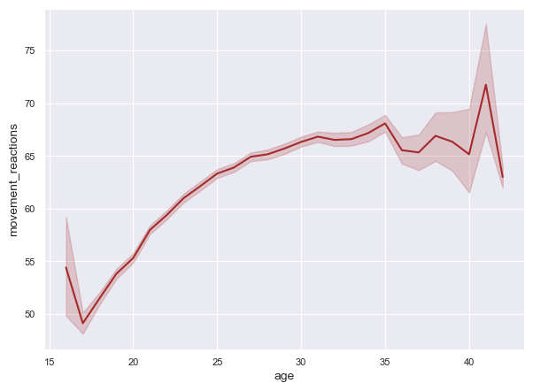

```python
plt.figure(figsize=(7,5))
sns.set_style('darkgrid')
sns.lineplot(x='age',y='movement_reactions',data=data,color='brown')
plt.show()
```

OBSERVATION:

At the age 15 to 20 movement raction is less. If player age is increasing player movement reaction also increasing.

2.IMPACT OF HEIGHT TO WEIGHT

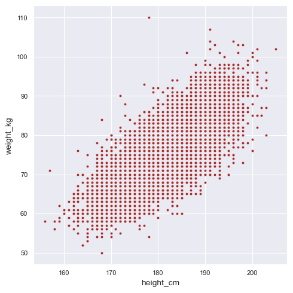

```python
sns.relplot(x='height_cm',y='weight_kg',data=data,color='brown')
plt.show()
```

OBSERVATION:

If the players height is increases player weight also increases.

3.RELATION BETWEEN OVERALL AND POTENTIAL WITH RESPECT TO PREFERRED FOOT

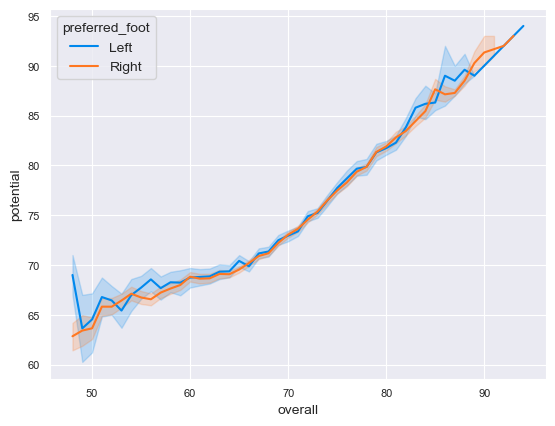

```python
sns.lineplot(x='overall',y='potential',data=data,color='brown',hue='preferred_foot')
plt.show()
```

OBSERVATION:

If the players overall score is increasing the score of potential also increasing with both foot.

4.RELATION BETWEEN VALUE EUR AND WAGE EURO WITH RESPECT TO PREFERRED FOOT

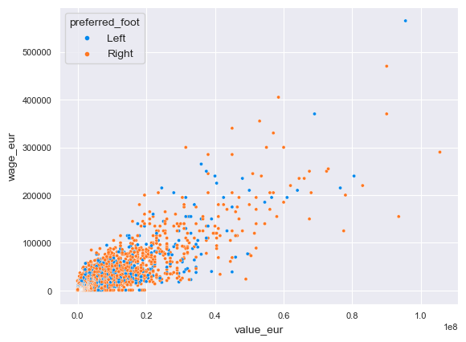

```python
sns.scatterplot(x='value_eur',y='wage_eur',data=data,color='brown',hue='preferred_foot')
plt.show()
```

OBSERVATION:

If player value is less then the wage of player also less. If the value of player is more the wage is silghtly more.

5.IMPACT OF CONTRACT VALID UNTIL TO RELEASE CLAUSE EUR

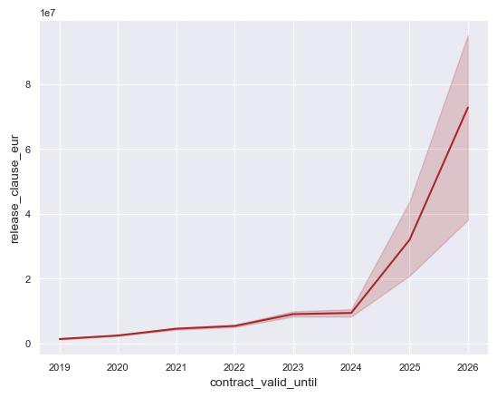

```python
sns.lineplot(x='contract_valid_until',y='release_clause_eur',data=data,color='brown')
plt.show()
```

OBSERVATION:

If player contract valid until 2024 to 2026 then the relase clause of player is more. If player contract valid until 2019 to 2024 then the release clause of player is less.

6..RELATION BETWEEN PACE AND SHOOTING WITH RESPECT TO PREFERRED FOOT

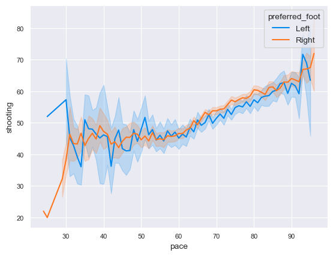

```python
sns.lineplot(x='pace',y='shooting',data=data,color='brown',hue='preferred_foot')
plt.show()
```

OBSERVATION:

If the player preferred left foot then the pace is less but shooting is around 50 to 60. If the player preferred right foot then the pace is less as well as shooting also less.

7.IMPCAT OF DRIBBLING TO DEFENDING

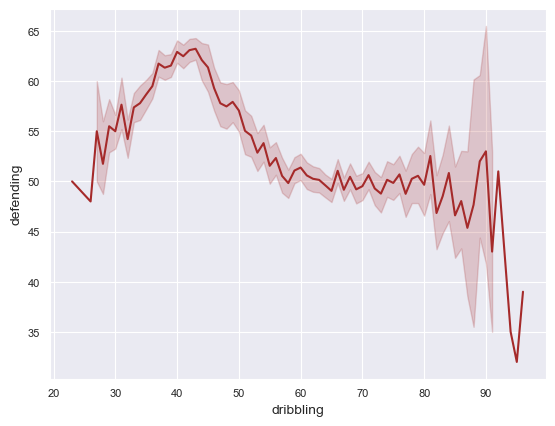

```python
sns.lineplot(x='dribbling',y='defending',data=data,color='brown')
plt.show()
```

OBSERVATION:

If the dribbling score is 30 to 50 then the defending score is high. If dribbling score is more then the defending score also less.

8.IMPACT OF PHYSIC TO ATTACKING CROSSING

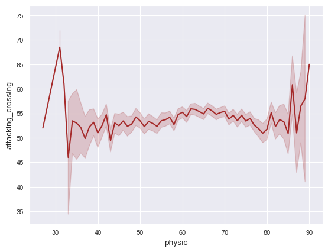

```python
sns.lineplot(x='physic',y='attacking_crossing',data=data,color='brown')
plt.show()
```

OBSERVATION:

If the physic is less then the attacking crossing is more. Otherwise physic range between 35 to 80 the attacking crossing is constant.

9.IMPACT OF GK DIVING TO GK HANDLING

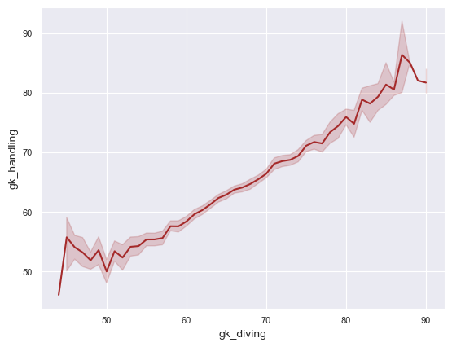

```python
sns.lineplot(x='gk_diving',y='gk_handling',data=data,color='brown')
plt.show()
```

OBSERVATION:

If the gk diving score is increases the gk handling score also increases.

10.IMPACT OF GK RELEXES TO GK SPPED

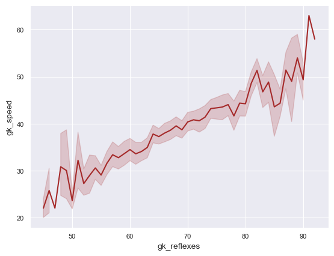

```python
sns.lineplot(x='gk_reflexes',y='gk_speed',data=data,color='brown')
plt.show()
```

OBSERVATION:

Less gk reflexes then the gk speed also less. More gk reflexes then the gk speed also more.

11.IMPACT OF GK POSITIONING TO GK KICKING

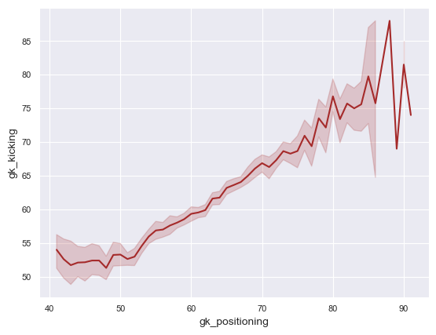

```python
sns.lineplot(x='gk_positioning',y='gk_kicking',data=data,color='brown')
plt.show()
```

OBSERVATION:

If the gk positioning score is less then the gk kicking score also less. If the gk positioning score is increases then the gk kicking score also increases.

12.IMPACT OF ATTACKING CROSSING TO ATTACKING FINISHING

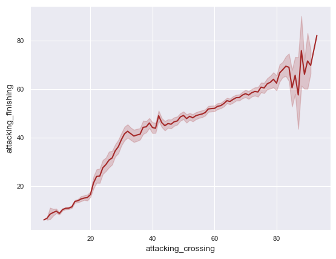

```python
sns.lineplot(x='attacking_crossing',y='attacking_finishing',data=data,color='brown')
plt.show()
```

OBSERVATION:

Attcking score between 20 to 40 then attacking finishing score around 40 to 50. Either attacking crossing is more then attacking finishing also more.

13.IMPACT OF ATTACKING SHORT PASSING TO ATTACKING VOLLEYS

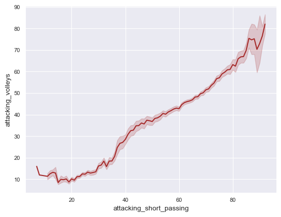

```python
sns.lineplot(x='attacking_short_passing',y='attacking_volleys',data=data,color='brown')
plt.show()
```

OBSERVATION:

More attacking short passing then the more attacking volleys. Less attacking short passing then the less attacking volleys.

14.IMPACT OF SKILL DRIBBLING TO SKILL BALL CONTROL

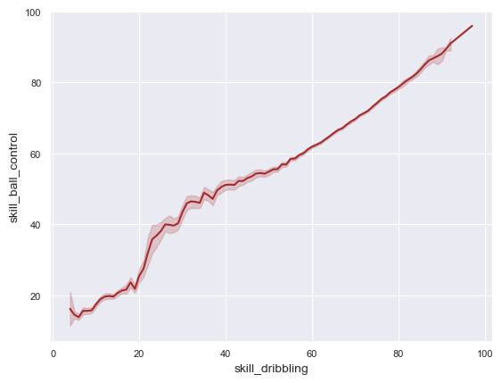

```python
sns.lineplot(x='skill_dribbling',y='skill_ball_control',data=data,color='brown')
plt.show()
```

OBSERVATION: If the dribbling skill is more then ball control skill also more.

15..RELATION BETWEEN SKILL CURVE AND SKILL FK ACCURACY WITH RESPECT TO PREFERRED FOOT

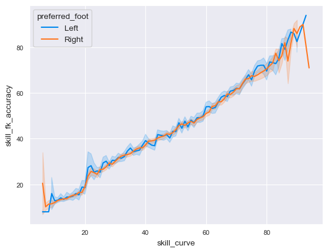

```python
sns.lineplot(x='skill_curve',y='skill_fk_accuracy',data=data,color='brown',hue='preferred_foot')
plt.show()
```

OBSERVATION:

If skill curve is increases then the skill fk accuracy is also increases with both foot.

16.IMPACT OF SKILL LONG PASSING TO POWER LONG SHOTS

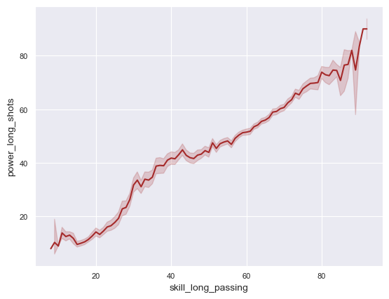

```python
sns.lineplot(x='skill_long_passing',y='power_long_shots',data=data,color='brown')
plt.show()
```

OBSERVATION:

More skills of long passing then the increase of power long shots.

17.IMPACT OF MOVEMENT SPRINT SPEED TO MOVEMENT REACTION

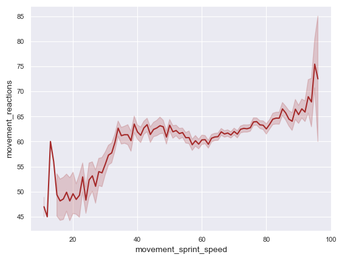

```python
sns.lineplot(x='movement_sprint_speed',y='movement_reactions',data=data,color='brown')
plt.show()
```

18.IMPACT OF POWER SHOT TO POWER STAMINA

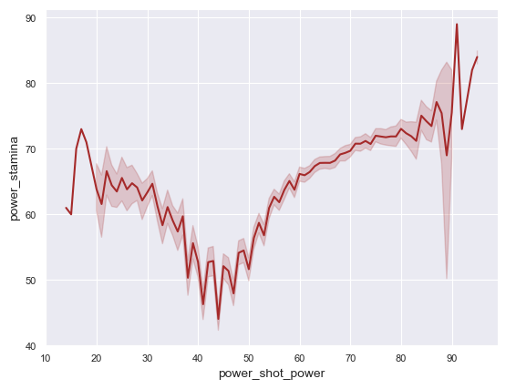

```python
sns.lineplot(x='power_shot_power',y='power_stamina',data=data,color='brown')
plt.show()
```

OBSERVATION:

19.IMPACT OF POWER JUMPING TO POWER STRENGTH

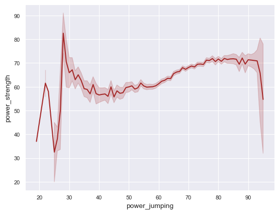

```python
sns.lineplot(x='power_jumping',y='power_strength',data=data,color='brown')
plt.show()
```

OBSERVATION:

If the power jumping is 30 then the power strength is more and below 30 power jumping less power strength. Power jumping above 30 then the power strength is constant

20.IMPACT TO MENTALITY AGGRESSION TO MENTALITY POSITIONING

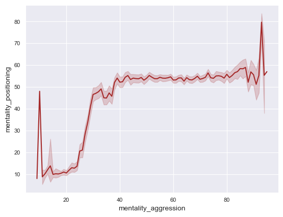

```python
sns.lineplot(x='mentality_aggression',y='mentality_positioning',data=data,color='brown')
plt.show()
```

OBSERVATION:

If the mentality aggression around 10 to 30 then the mentality positioning is low Below 10 mentality aggression the score of mentality positioning is slightly high. otherwise both metality positioning score is constant.

21.IMPACT OF MENTALITY PENALTIES TO MENTALITY VISION

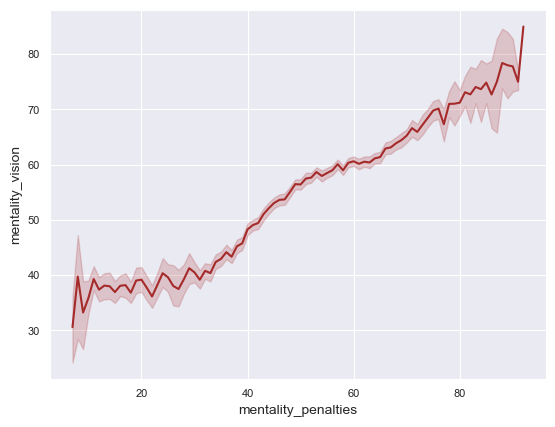

```python
sns.lineplot(x='mentality_penalties',y='mentality_vision',data=data,color='brown')
plt.show()
```

OBSERVATION:

If the penalties is increases then the mentality vision also increases.

22.RELATION BETWEEN DEFENDING STANDING TACKLE & DEFENDING SLIDING TACKLE WITH RESPECT TO PREFERRED FOOT

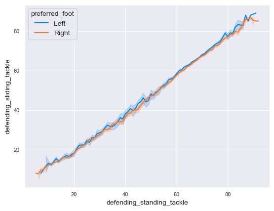

```python
sns.lineplot(x='defending_standing_tackle',y='defending_sliding_tackle',data=data,color='brown',hue='preferred_foot')
plt.show()
```

OBSERVATION:

If defending standing tackle is increases then the defending sliding tackle also increases with both foot.

# CATEGORICAL VARIABLE

1.IMPACT OF INTERNATIONAL REPUTATION TO WEAK FOOT

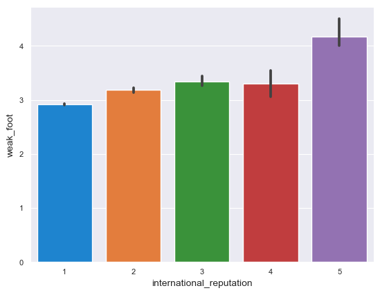

```python
sns.barplot(x='international_reputation',y='weak_foot',data=data)
plt.show()
```

OBSERVATION:

5 Intrenational reputation rating of player has more than 4 week foot 1 international reputation rating player has less than 3 weak foot 2, 3, 4 international reputation player has constant weak foot

2.IMPACT OF WORK RATE TO SKILL MOVES

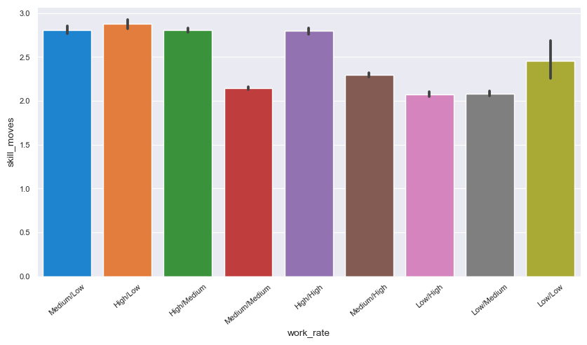

```python
plt.figure(figsize=(10,5))
sns.barplot(x='work_rate',y='skill_moves',data=data)
plt.xticks(rotation=40)
plt.show()
```

OBSERVATION:

In this plot cleary seen that 4 types of work rate[medium/low, high/low, high/medium, high/high] has more than 2.5 skill moves Other work rate skill moves is less than 2.5

3.IMPACT OF REAL FACE TO RELEASE CLAUSE EUR

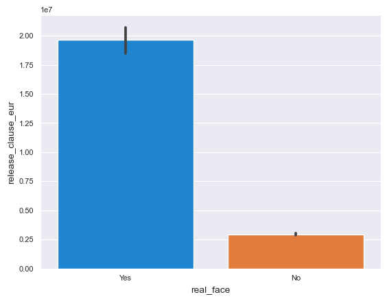

```python
sns.barplot(x='real_face',y='release_clause_eur',data=data)
plt.show()
```

OBSERVATION:

If the player face is real then the release clause is more. If the player face is not real then the release clause is less

4.IMPACT OF PREFERRED FOOT TO PACE

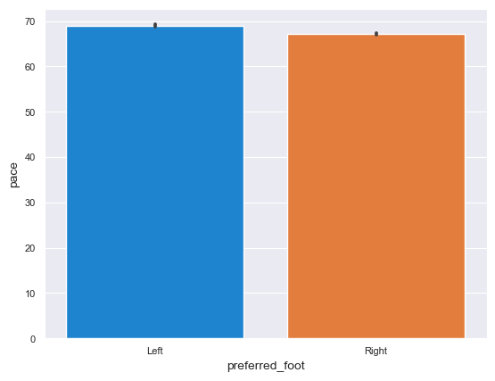

```python
sns.barplot(x='preferred_foot',y='pace',data=data)
plt.show()
```

OBSERVATION:

both left and right preferred foot player pace is same.

5.IMPACT OF TEAM POSITION TO SHOOTING

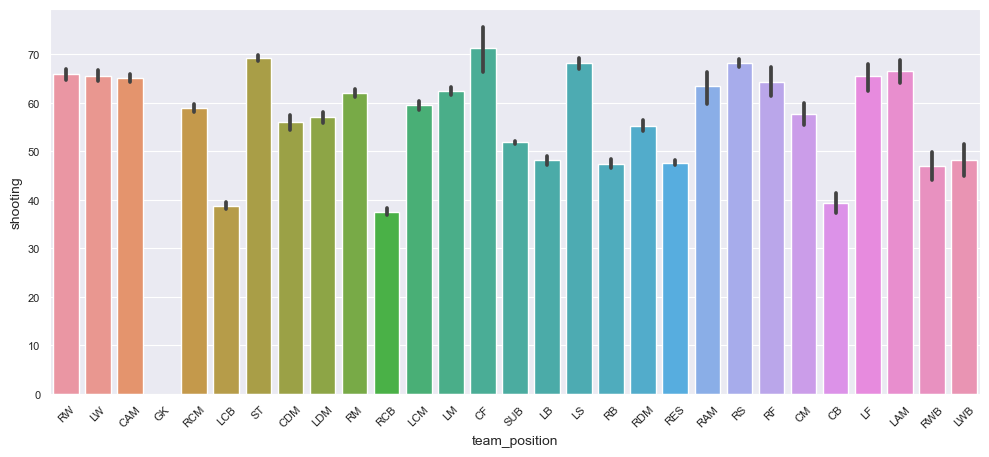

```python
plt.figure(figsize=(12,5))
sns.barplot(x='team_position',y='shooting',data=data)
plt.xticks(rotation=45)
plt.show()
```

OBSERVATION:

In this plot we clearly seent that GK team position has no shooting score. CF team position has maximum shooting score.

# HERE SOME CONDITION & PLOTTING

1.TOP 10 NATIONALITY PLAYER

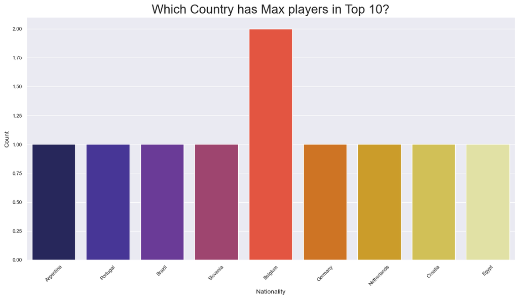

```python
plt.figure(figsize=(14,7))
sns.countplot(x='nationality',data=data.head(10),palette='CMRmap')
plt.xlabel('Nationality')
plt.ylabel('Count')
plt.xticks(rotation=45) # used to tild the name on x axis
plt.title('Which Country has Max players in Top 10?',fontsize = 20)
plt.show()
```

OBSERVATION:

Most of the belgium country player in to 10

2.TOP 10 CLUB PLAYER

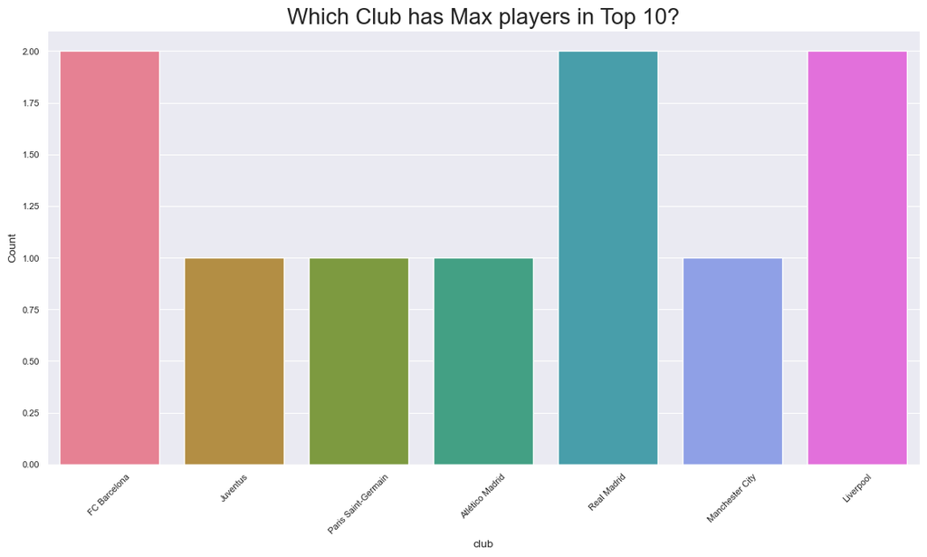

```python
plt.figure(figsize=(14,7))
sns.countplot(x='club',data=data.head(10),palette='husl')
plt.xlabel('club')
plt.ylabel('Count')
plt.xticks(rotation=45) # used to tild the name on x axis
plt.title('Which Club has Max players in Top 10?',fontsize = 20)
plt.show()
```

OBSERVATION:

most of the Fc Barcelona. real madrid, and liver pool club player in top 10.

3.TEAM POSITION IN TOP 10

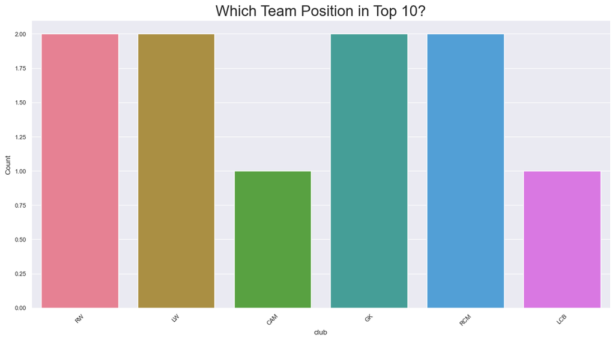

```python
plt.figure(figsize=(14,7))
sns.countplot(x='team_position',data=data.head(10),palette='husl')
plt.xlabel('club')
plt.ylabel('Count')
plt.xticks(rotation=45) # used to tild the name on x axis
plt.title('Which Team Position in Top 10?',fontsize = 20)
plt.show()
```

OBSERVATION:

Most of the RW, LW, GK, RCM team position in top 10

4.CAMPARE MESSI VS RONALDO

```python
feature = data[['short_name','overall','potential','pace','shooting','passing','dribbling','defending','physic']]
compare = feature.head(2)
compare = compare.set_index('short_name')
compare.head()
```

| short_name | overall | potential | pace | shooting | passing | dribbling | defending | physic |
| --- | --- | --- | --- | --- | --- | --- | --- | --- |
| L. Messi | 94 | 94 | 87.0 | 92.0 | 92.0 | 96.0 | 39.0 | 66.0 |
| Cristiano Ronaldo | 93 | 93 | 90.0 | 93.0 | 82.0 | 89.0 | 35.0 | 78.0 |

5.GET TOP 5 MAXIMUM VALUE PLAYER WITH MINIMUM RELEASE

```python
data.sort_values(by=['value_eur','release_clause_eur'],ascending=[0,1]).head()
```

|  | sofifa_id | player_url | short_name | long_name | age | dob | height_cm | weight_kg | nationality | club | overall | potential | value_eur | wage_eur | player_positions | preferred_foot | international_reputation | weak_foot | skill_moves | work_rate | body_type | real_face | release_clause_eur | player_tags | team_position | team_jersey_number | loaned_from | joined | contract_valid_until | … |
| --- | --- | --- | --- | --- | --- | --- | --- | --- | --- | --- | --- | --- | --- | --- | --- | --- | --- | --- | --- | --- | --- | --- | --- | --- | --- | --- | --- | --- | --- | --- |
| 2 | 190871 | https://sofifa.com/player/190871/neymar-da-sil... | Neymar Jr | Neymar da Silva Santos Junior | 27 | 1992-02-05 | 175 | 68 | Brazil | Paris Saint-Germain | 92 | 92 | 105500000 | 290000 | LW, CAM | Right | 5 | 5 | 5 | High/Medium | Neymar | Yes | 195200000.0 | Speedster, Dribbler, Playmaker , Crosser, FK ... | CAM | 10.0 | NaN | 2017-08-03 | 2022.0 | … |
| 0 | 158023 | https://sofifa.com/player/158023/lionel-messi/... | L. Messi | Lionel Andrés Messi Cuccittini | 32 | 1987-06-24 | 170 | 72 | Argentina | FC Barcelona | 94 | 94 | 95500000 | 565000 | RW, CF, ST | Left | 5 | 4 | 4 | Medium/Low | Messi | Yes | 195800000.0 | Dribbler, Distance Shooter, Crosser, FK Specia... | RW | 10.0 | NaN | 2004-07-01 | 2021.0 | … |
| 10 | 231747 | https://sofifa.com/player/231747/kylian-mbappe... | K. Mbappé | Kylian Mbappé | 20 | 1998-12-20 | 178 | 73 | France | Paris Saint-Germain | 89 | 95 | 93500000 | 155000 | ST, RW | Right | 3 | 4 | 5 | High/Low | Normal | Yes | 191700000.0 | Speedster, Dribbler, Acrobat | RW | 7.0 | NaN | 2018-07-01 | 2022.0 | … |
| 5 | 192985 | https://sofifa.com/player/192985/kevin-de-bruy... | K. De Bruyne | Kevin De Bruyne | 28 | 1991-06-28 | 181 | 70 | Belgium | Manchester City | 91 | 91 | 90000000 | 370000 | CAM, CM | Right | 4 | 5 | 4 | High/High | Normal | Yes | 166500000.0 | Dribbler, Playmaker , Engine, Distance Shoote... | RCM | 17.0 | NaN | 2015-08-30 | 2023.0 | … |
| 4 | 183277 | https://sofifa.com/player/183277/eden-hazard/2... | E. Hazard | Eden Hazard | 28 | 1991-01-07 | 175 | 74 | Belgium | Real Madrid | 91 | 91 | 90000000 | 470000 | LW, CF | Right | 4 | 4 | 4 | High/Medium | Normal | Yes | 184500000.0 | Speedster, Dribbler, Acrobat | LW | 7.0 | NaN | 2019-07-01 | 2024.0 | … |

# DATA PREPROCESSING / FEATURE ENGINEERING

1.CHECK MISSING VALUE

```python
pd.set_option('display.max_rows',None)
data.isnull().sum()
```

```
sofifa_id                         0
player_url                        0
short_name                        0
long_name                         0
age                               0
dob                               0
height_cm                         0
weight_kg                         0
nationality                       0
club                              0
overall                           0
potential                         0
value_eur                         0
wage_eur                          0
player_positions                  0
preferred_foot                    0
international_reputation          0
weak_foot                         0
skill_moves                       0
work_rate                         0
body_type                         0
real_face                         0
release_clause_eur             1298
player_tags                   16779
team_position                   240
team_jersey_number              240
loaned_from                   17230
joined                         1288
contract_valid_until            240
nation_position               17152
nation_jersey_number          17152
pace                           2036
shooting                       2036
passing                        2036
dribbling                      2036
defending                      2036
physic                         2036
gk_diving                     16242
gk_handling                   16242
gk_kicking                    16242
```

[output cut: 50 more lines]

```
lcm                            2036
cm                             2036
rcm                            2036
rm                             2036
lwb                            2036
ldm                            2036
cdm                            2036
rdm                            2036
rwb                            2036
lb                             2036
lcb                            2036
cb                             2036
rcb                            2036
rb                             2036
dtype: int64
```

```python
# Create function to check missing value with percentage
def missing_value(data):
    null_value = data.isnull().sum()
    percentage = (data.isnull().sum()/data.isnull().count()*100)
    null_value = pd.concat([null_value,percentage],axis=1,keys=['Missing Number','Missing Percentage'])
    return null_value
missing_value(data)
```

|  | Missing Number | Missing Percentage |
| --- | --- | --- |
| sofifa_id | 0 | 0.000000 |
| player_url | 0 | 0.000000 |
| short_name | 0 | 0.000000 |
| long_name | 0 | 0.000000 |
| age | 0 | 0.000000 |
| dob | 0 | 0.000000 |
| height_cm | 0 | 0.000000 |
| weight_kg | 0 | 0.000000 |
| nationality | 0 | 0.000000 |
| club | 0 | 0.000000 |
| overall | 0 | 0.000000 |
| potential | 0 | 0.000000 |
| value_eur | 0 | 0.000000 |
| wage_eur | 0 | 0.000000 |
| player_positions | 0 | 0.000000 |
| preferred_foot | 0 | 0.000000 |
| international_reputation | 0 | 0.000000 |
| weak_foot | 0 | 0.000000 |
| skill_moves | 0 | 0.000000 |
| work_rate | 0 | 0.000000 |
| body_type | 0 | 0.000000 |
| real_face | 0 | 0.000000 |
| release_clause_eur | 1298 | 7.101433 |
| player_tags | 16779 | 91.798884 |
| team_position | 240 | 1.313054 |
| team_jersey_number | 240 | 1.313054 |
| loaned_from | 17230 | 94.266331 |
| joined | 1288 | 7.046723 |
| contract_valid_until | 240 | 1.313054 |
| nation_position | 17152 | 93.839589 |

[output cut: 74 more lines]

# 2.IMPUTE MISSING VALUE

CHECKING THE DISTRIBUTION BEFORE IMPUTE MISSING VALUE

1.NUMERICAL

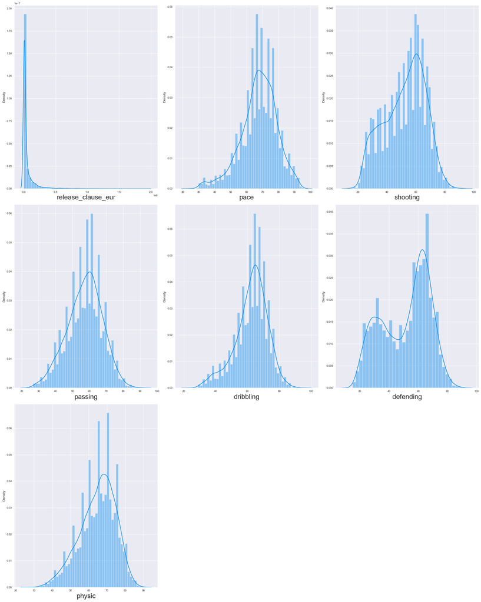

```python
dist = data[['release_clause_eur','pace','shooting','passing','dribbling','defending','physic']]

plt.figure(figsize=(20,25)) # defining canvas size
plotno = 1 # counter

for column in dist: # iteration of columns / acessing the columns from  dataset
    if plotno<=8:    # set the limit
        plt.subplot(3,3,plotno) # # plotting 36 graphs (9-rows,4-columns) ,plotnumber is for count
        sns.distplot(x=dist[column]) # Plotting dist plots
        plt.xlabel(column,fontsize=20)  # assigning name to x-axis and font size is 20
    plotno+=1 # counter increment
plt.tight_layout()
plt.show() # used to hide the storage loction
```

```python
# Impute missing value using median because distribution is not normal
data.loc[data['release_clause_eur'].isnull()==True,'release_clause_eur']=data['release_clause_eur'].median()
data.loc[data['pace'].isnull()==True,'pace']=data['pace'].median()
data.loc[data['shooting'].isnull()==True,'shooting']=data['shooting'].median()
data.loc[data['passing'].isnull()==True,'passing']=data['passing'].median()
data.loc[data['dribbling'].isnull()==True,'dribbling']=data['dribbling'].median()
data.loc[data['defending'].isnull()==True,'defending']=data['defending'].median()
data.loc[data['physic'].isnull()==True,'physic']=data['physic'].median()
```

```python
# Check missing value after imputation
print('release_clause_eur:',data['release_clause_eur'].isnull().sum())
print('pace:',data['pace'].isnull().sum())
print('shooting:',data['shooting'].isnull().sum())
print('passing:',data['passing'].isnull().sum())
print('dribbling:',data['dribbling'].isnull().sum())
print('defending:',data['defending'].isnull().sum())
print('physic:',data['physic'].isnull().sum())
```

```
release_clause_eur: 0
pace: 0
shooting: 0
passing: 0
dribbling: 0
defending: 0
physic: 0
```

2.CATEGORICAL

```python
# Get the value counts
data.team_position.value_counts().head()
```

```
team_position
SUB    7820
RES    2958
GK      662
RCB     660
LCB     660
Name: count, dtype: int64
```

```python
# Impute categorical data using mode(most freqent)
data['team_position'] = data['team_position'].replace(np.nan,'SUB')
```

```python
# Check missing value after imputation
data['team_position'].isnull().sum()
```

```
0
```